# Informações da pesquisa

### Tamanho da população

27.847 emails enviados

### Tamanho da Amostra

Obtivemos um total de 965 respostas, com sua 95% das respostas ocorrendo entre 08 e 10 de maio de 2020.

### Grau de confiança atingido

#### Grau de Confiança é a probabilidade de que a amostra represente com precisão a opinião da população em questão.

Com o tamanho da amostra obtida, alcançamos 95% de grau de confiança.

### Margem de erro atingido

#### Margem de Erro é a variação (medida como porcentagem) que as respostas da população podem ter em relação à amostra.

Com o tamanho da amostra obtida, alcançamos uma Margem de Erro de apenas 3,1%.

### Importando as bibliotecas necessárias

```python
import numpy as np
import pandas as pd
import seaborn as sns
from matplotlib import pyplot as plt
```

### Carregando o arquivo

```python
data = pd.read_csv('C:/Users/Leonardo/Documents/R2/Estudos de Mercado/Mailing - Impacto da pandemia no comportamento social (respostas) - Respostas ao formulário 1.csv')
pd.set_option("display.max_columns", 200)
data.head()
```

|  | Carimbo de data/hora | Qual data do seu nascimento? | Com qual gênero você se identifica? | Qual o nível de isolamento que você está vivendo hoje? | Você já fez o exame de COVID-19? | Um local que você quer ir cobra um exame de COVID na porta, você faria para entrar? | Qual o impacto financeiro na sua casa pela pandemia? | Do que você está com mais saudade? | Você se sente seguro saindo no seu carro e indo a um Drive Thru? | Saindo um novo decreto liberando aglomerações, shows e eventos, você se sentiria seguro de ir? | Você possui alguém do grupo de risco em casa? Grupo de risco: idosos (50+), crianças, grávidas, enfermidades | Sabendo que você não tem uma pessoa do grupo de risco em casa, você iria para um evento? |
| --- | --- | --- | --- | --- | --- | --- | --- | --- | --- | --- | --- | --- |
| 0 | 06/05/2020 11:59:21 | 10/03/2003 | Masculino | Isolamento total (saio de casa apenas em emerg... | Não, porque estou bem | Talvez (mas acho meio esquisito) | Algumas pequenas mudanças, mas nada grave | Eventos/Shows | 4 | Ainda não, apenas com protocolos de saúde (más... | Não | Sim |
| 1 | 06/05/2020 12:01:02 | 29/10/2003 | Feminino | Isolamento total (saio de casa apenas em emerg... | Não, porque estou bem | Sim (e acho massa) | Algumas pequenas mudanças, mas nada grave | Academia | 3 | Não | Não | Não |
| 2 | 06/05/2020 12:01:18 | 20/07/2002 | Masculino | Isolamento total (saio de casa apenas em emerg... | Não, porque estou bem | Talvez (mas acho meio esquisito) | Algumas pequenas mudanças, mas nada grave | Eventos/Shows | 5 | Não | Sim | NaN |
| 3 | 06/05/2020 12:02:25 | 03/07/2002 | Feminino | Isolamento total (saio de casa apenas em emerg... | Não, porque estou bem | Sim (e acho massa) | Algumas pequenas mudanças, mas nada grave | Barzinho | 3 | Não | Sim | NaN |
| 4 | 06/05/2020 12:03:38 | 11/12/2003 | Masculino | Isolamento parcial/intermitente (saio uma vez ... | Não, porque estou bem | Talvez (mas acho meio esquisito) | Não fui impactado, vida normal | Eventos/Shows | 1 | Sim | Sim (mas isolado dos demais) | NaN |

### Qual a distribuição de gênero?

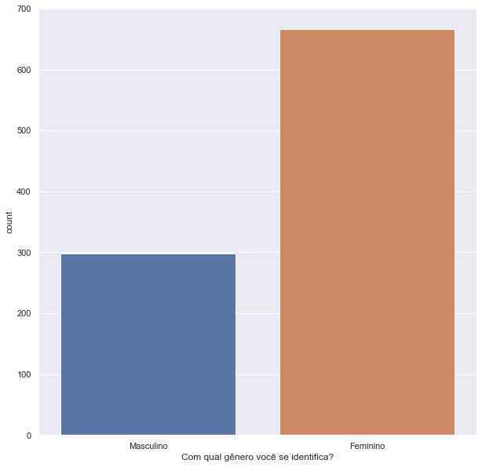

```python
sns.set(style="darkgrid")
fig,ax = plt.subplots(1,1, figsize=(10,10))
genero = sns.countplot(x="Com qual gênero você se identifica?", data=data)
```

### Qual o nível de isolamento social?

[output not shown]

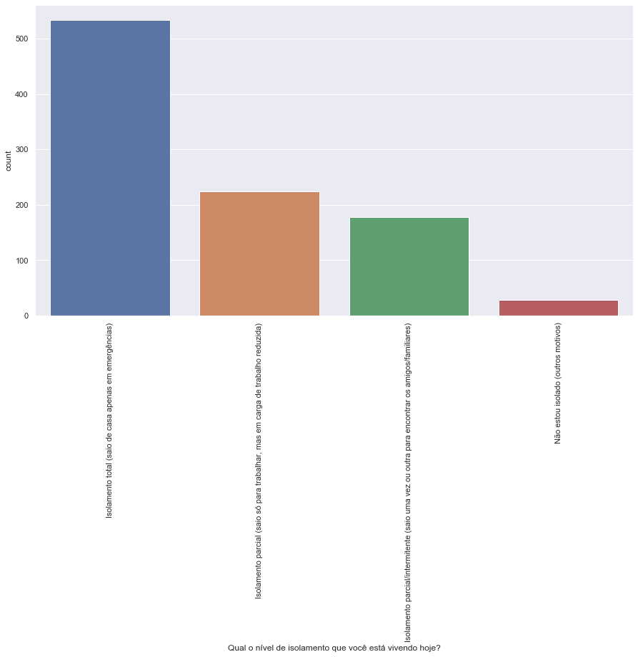

```python
fig,ax = plt.subplots(1,1, figsize=(15,8))
isolamento = sns.countplot(x="Qual o nível de isolamento que você está vivendo hoje?", data=data, order = data["Qual o nível de isolamento que você está vivendo hoje?"].value_counts().index)
isolamento.set_xticklabels(isolamento.get_xticklabels(), rotation=90)
```

## Qual a relação entre gênero e nível de isolamento social?

```python
data.groupby(["Qual o nível de isolamento que você está vivendo hoje?"])["Com qual gênero você se identifica?"].value_counts().sort_values(ascending=False)
```

```
Qual o nível de isolamento que você está vivendo hoje?                                       Com qual gênero você se identifica?
Isolamento total (saio de casa apenas em emergências)                                        Feminino                               394
                                                                                             Masculino                              140
Isolamento parcial (saio só para trabalhar, mas em carga de trabalho reduzida)               Feminino                               136
Isolamento parcial/intermitente (saio uma vez ou outra para encontrar os amigos/familiares)  Feminino                               119
Isolamento parcial (saio só para trabalhar, mas em carga de trabalho reduzida)               Masculino                               88
Isolamento parcial/intermitente (saio uma vez ou outra para encontrar os amigos/familiares)  Masculino                               59
Não estou isolado (outros motivos)                                                           Feminino                                18
                                                                                             Masculino                               11
Name: Com qual gênero você se identifica?, dtype: int64
```

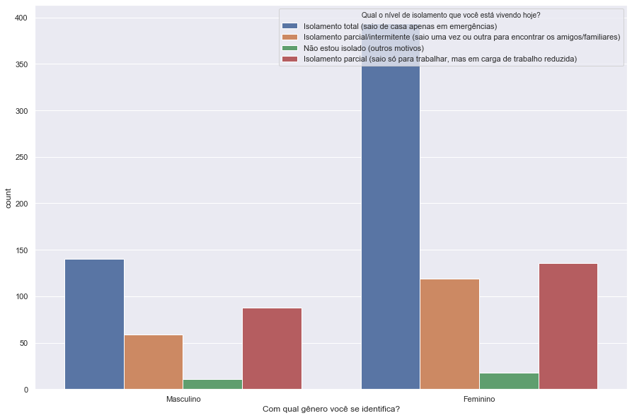

```python
fig,ax = plt.subplots(1,1, figsize=(15,10))
genero_isolamento = sns.countplot(x="Com qual gênero você se identifica?", hue="Qual o nível de isolamento que você está vivendo hoje?", data=data)
```

## Qual a matriz de correlação entre gênero e nível de isolamento social?

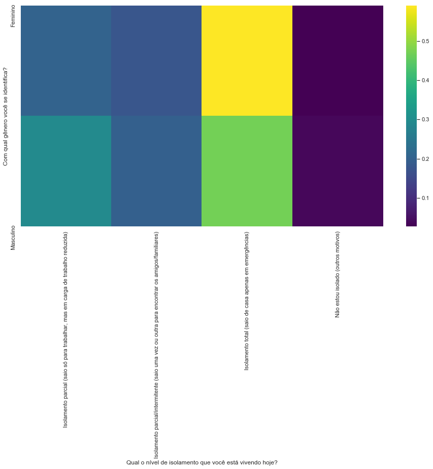

```python
fig,ax = plt.subplots(1,1, figsize=(16,8))
degree = data.groupby(["Com qual gênero você se identifica?", "Qual o nível de isolamento que você está vivendo hoje?"]).size().unstack()#.fillna(0)
degree = degree.div(degree.sum(axis=1), axis=0)
sns.heatmap(degree, cmap='viridis')
```

### Quem já fez exame do COVID-19

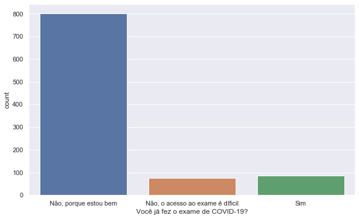

```python
fig,ax = plt.subplots(1,1, figsize=(10,6))
exame = sns.countplot(x="Você já fez o exame de COVID-19?", data=data)
```

### Faria exame pra entrar num local?

[output not shown]

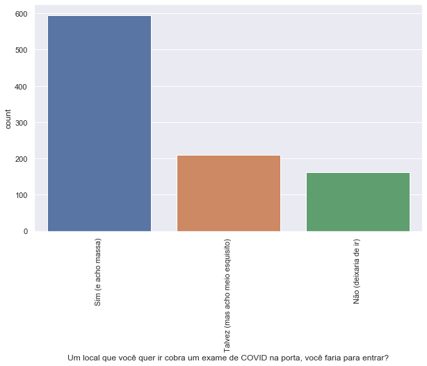

```python
fig,ax = plt.subplots(1,1, figsize=(10,6))
exame_porta = sns.countplot(x="Um local que você quer ir cobra um exame de COVID na porta, você faria para entrar?", data=data, order = data["Um local que você quer ir cobra um exame de COVID na porta, você faria para entrar?"].value_counts().index)
exame_porta.set_xticklabels(exame_porta.get_xticklabels(), rotation=90)
```

## Qual a relação entre quem já fez o exame e faria para entrar em algum lugar

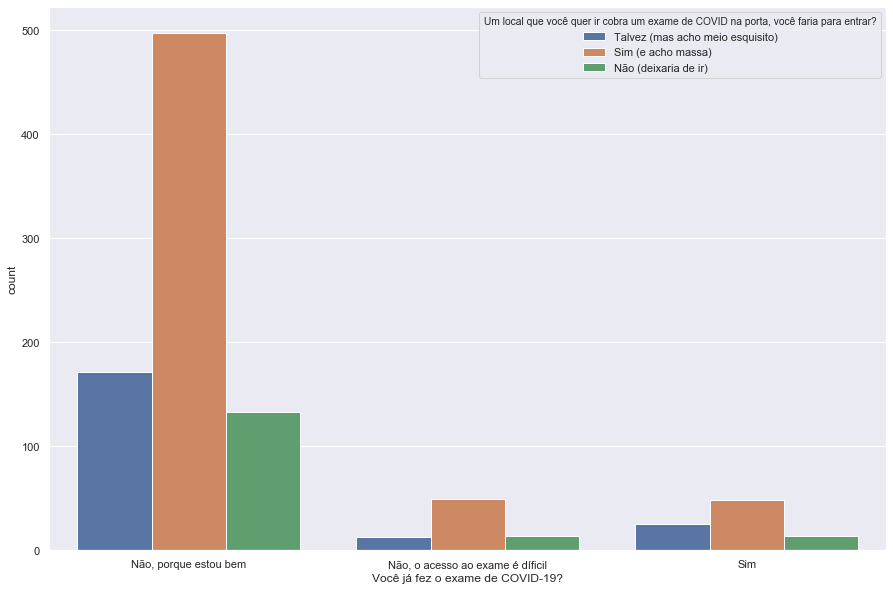

```python
fig,ax = plt.subplots(1,1, figsize=(15,10))
exame_porta_jafez = sns.countplot(x="Você já fez o exame de COVID-19?", hue="Um local que você quer ir cobra um exame de COVID na porta, você faria para entrar?", data=data)
```

### Qual o impacto na vida financeira?

[output not shown]

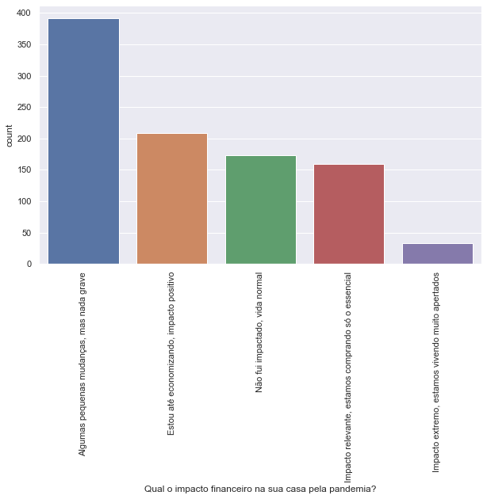

```python
fig,ax = plt.subplots(1,1, figsize=(10,6))
impacto = sns.countplot(x="Qual o impacto financeiro na sua casa pela pandemia?", data=data, order = data["Qual o impacto financeiro na sua casa pela pandemia?"].value_counts().index)
impacto.set_xticklabels(impacto.get_xticklabels(), rotation=90)
```

### Do que as pessoas mais sentem saudades?

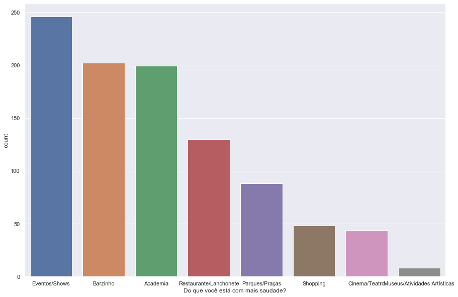

```python
fig,ax = plt.subplots(1,1, figsize=(15,10))
sente_falta = sns.countplot(x="Do que você está com mais saudade?", data=data, order = data["Do que você está com mais saudade?"].value_counts().index)
```

## Matriz de correlação entre o impacto financeiro e o que mais sente falta

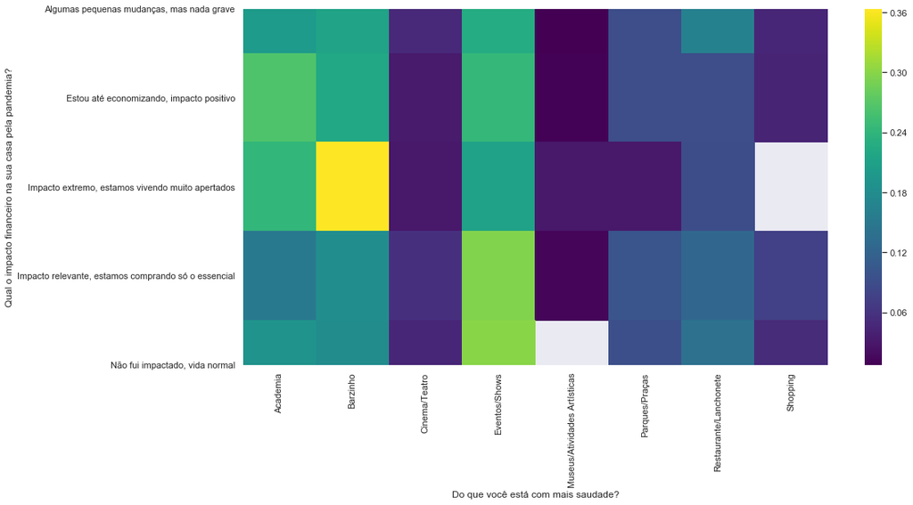

```python
fig,ax = plt.subplots(1,1, figsize=(16,8))
degree = data.groupby(["Qual o impacto financeiro na sua casa pela pandemia?","Do que você está com mais saudade?"]).size().unstack()#.fillna(0)
degree = degree.div(degree.sum(axis=1), axis=0)
sns.heatmap(degree, cmap='viridis')
```

## Relação entre impacto financeiro e segurança em ir para um Drive In (com variação de respostas)

[output not shown]

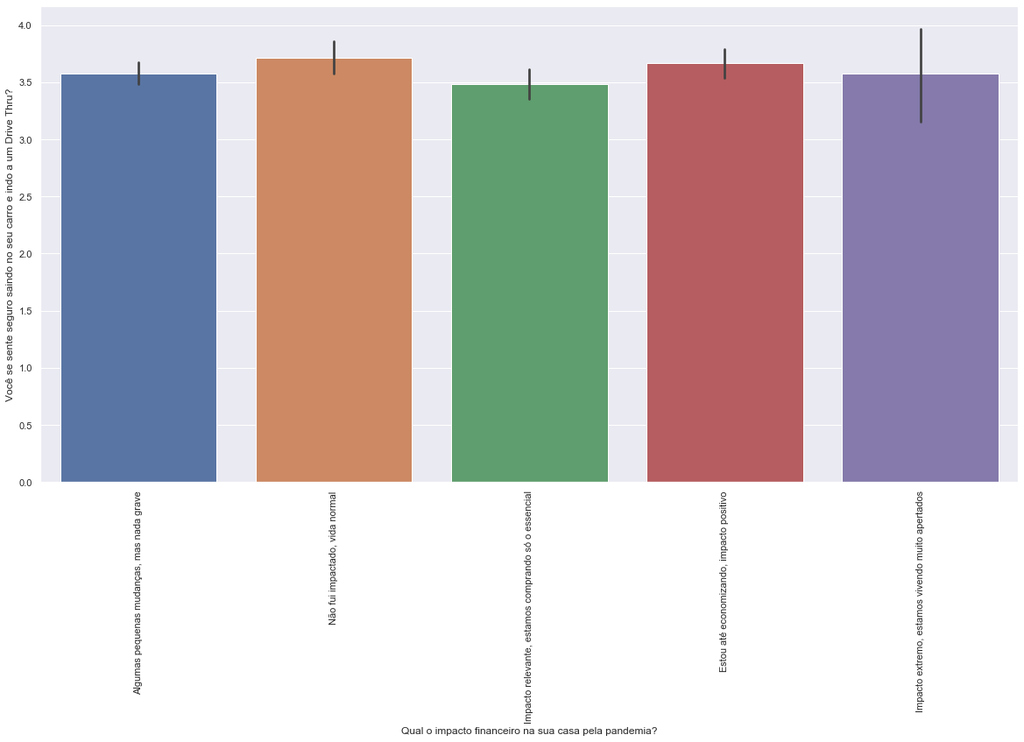

```python
fig,ax = plt.subplots(1,1, figsize=(20,10))
plote = sns.barplot(x="Qual o impacto financeiro na sua casa pela pandemia?", y="Você se sente seguro saindo no seu carro e indo a um Drive Thru?", data=data)
plote.set_xticklabels(plote.get_xticklabels(), rotation=90)
```

## Relação entre o que mais sente falta e segurança em ir para um Drive In (com variação de respostas)

[output not shown]

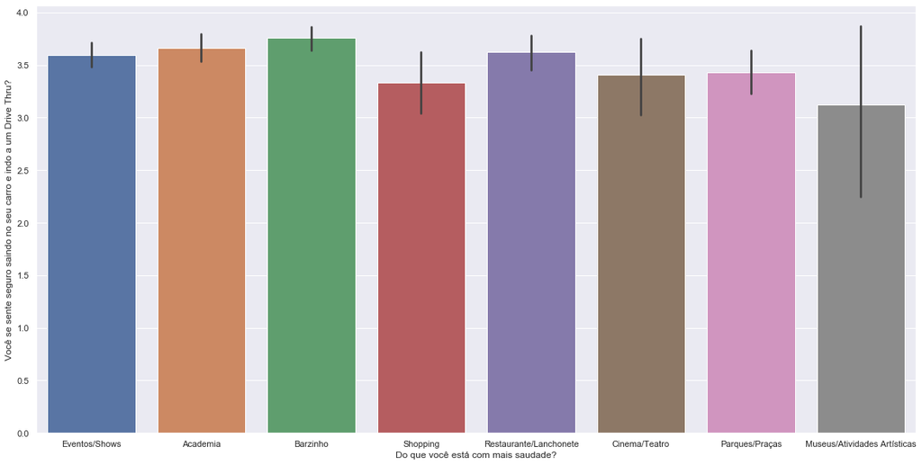

```python
fig,ax = plt.subplots(1,1, figsize=(20,10))
plote = sns.barplot(x="Do que você está com mais saudade?", y="Você se sente seguro saindo no seu carro e indo a um Drive Thru?", data=data)
plote.set_xticklabels(plote.get_xticklabels(), rotation=0)
```

## Possuem pessoas do grupo de risco em casa?

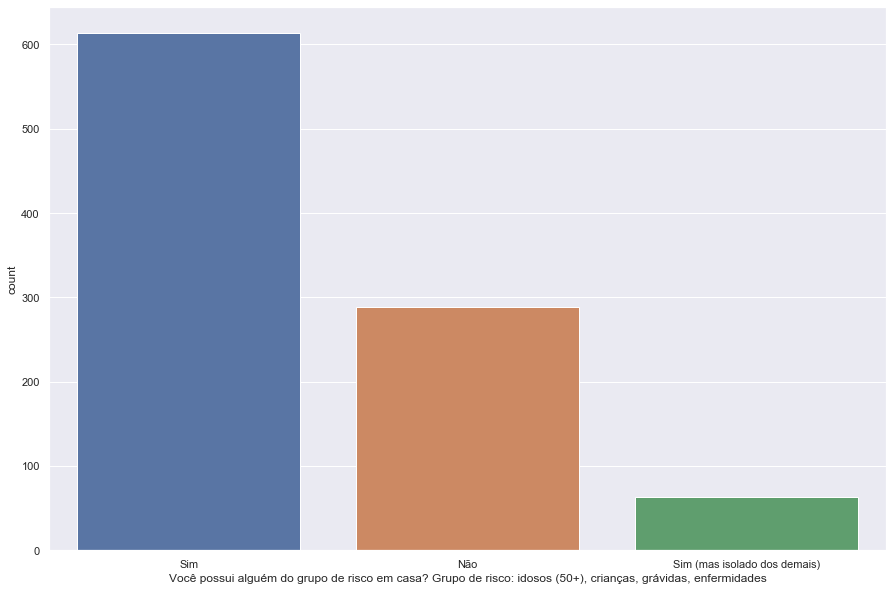

```python
fig,ax = plt.subplots(1,1, figsize=(15,10))
sente_falta = sns.countplot(x="Você possui alguém do grupo de risco em casa? Grupo de risco: idosos (50+), crianças, grávidas, enfermidades", data=data, order = data["Você possui alguém do grupo de risco em casa? Grupo de risco: idosos (50+), crianças, grávidas, enfermidades"].value_counts().index)
```

## Matriz de correlação entre o impacto financeiro e existência de grupo de risco em casa

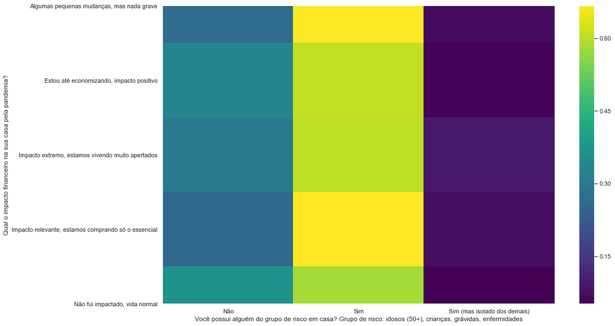

```python
fig,ax = plt.subplots(1,1, figsize=(16,10))
degree = data.groupby(["Qual o impacto financeiro na sua casa pela pandemia?","Você possui alguém do grupo de risco em casa? Grupo de risco: idosos (50+), crianças, grávidas, enfermidades"]).size().unstack()#.fillna(0)
degree = degree.div(degree.sum(axis=1), axis=0)
sns.heatmap(degree, cmap='viridis')
```

## Matriz de correlação entre existência de grupo de risco em casa e segurança para ida em um Drive In

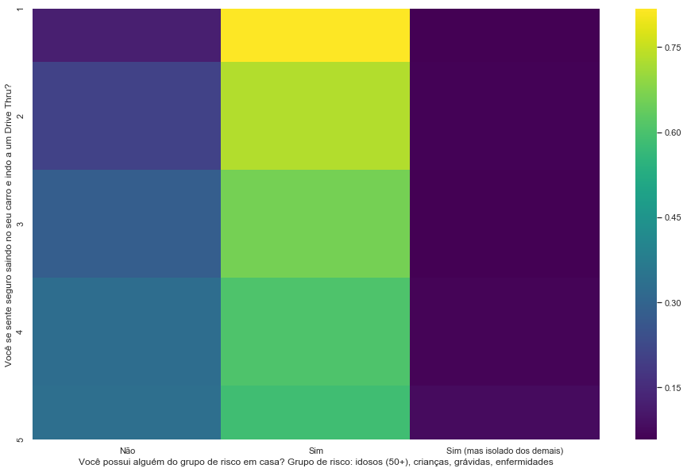

```python
fig,ax = plt.subplots(1,1, figsize=(16,10))
degree = data.groupby(["Você se sente seguro saindo no seu carro e indo a um Drive Thru?", "Você possui alguém do grupo de risco em casa? Grupo de risco: idosos (50+), crianças, grávidas, enfermidades"]).size().unstack()#.fillna(0)
degree = degree.div(degree.sum(axis=1), axis=0)
sns.heatmap(degree, cmap='viridis')
```

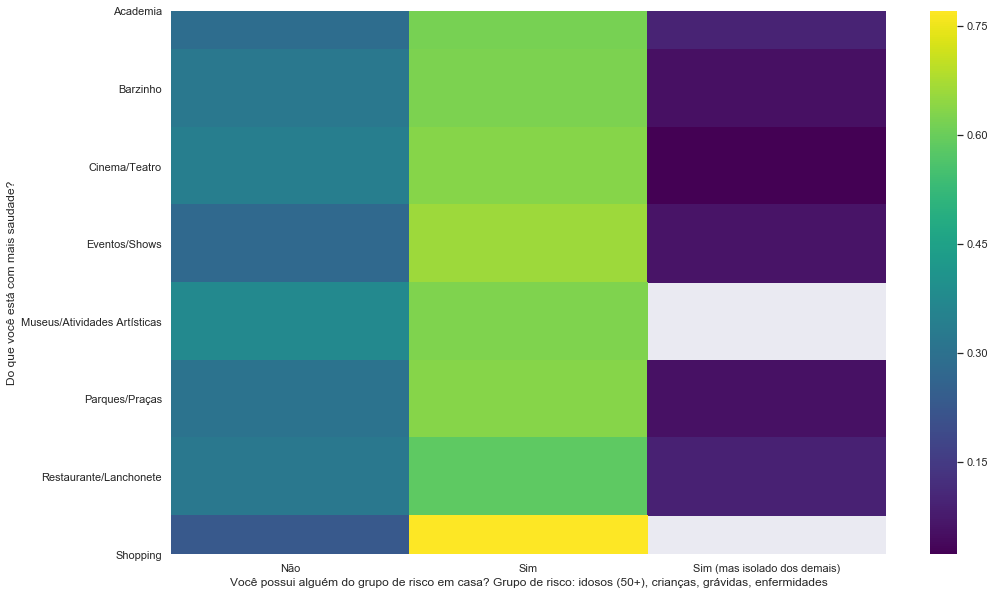

```python
fig,ax = plt.subplots(1,1, figsize=(16,10))
degree = data.groupby(["Do que você está com mais saudade?", "Você possui alguém do grupo de risco em casa? Grupo de risco: idosos (50+), crianças, grávidas, enfermidades"]).size().unstack()#.fillna(0)
degree = degree.div(degree.sum(axis=1), axis=0)
sns.heatmap(degree, cmap='viridis')
```